# Biostat 212a Homework 5

## 2 ISL Exercise 9.7.2 (10pts)

We have seen that in p = 2 dimensions, a linear decision boundary takes the form $β_0 +β_1X_1 +β_2X_2 = 0$. We now investigate a non-linear decision boundary.

1. Sketch the curve $(1 + X_1)^2 + (2 − X_2)^2 = 4$.

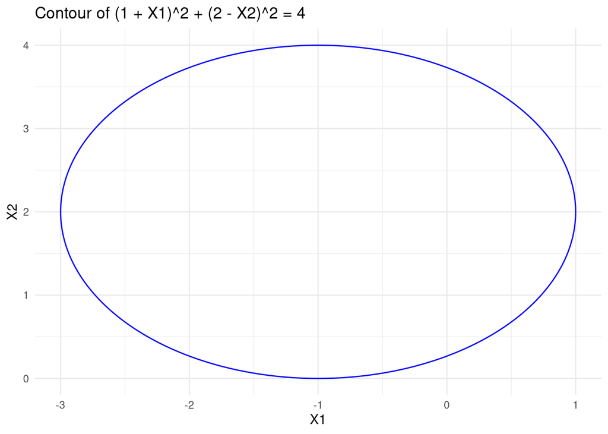

```r
library(ggplot2)

# Function to calculate the circle's radius squared
radius_squared <- function(x, y) {
  (1 + x)^2 + (2 - y)^2
}

# Define the range for X1 and X2 and create a data frame
x_range <- seq(-4, 2, length.out = 300)
y_range <- seq(0, 4, length.out = 300)
df <- expand.grid(X1 = x_range, X2 = y_range)

# Calculate the Z values (the radius squared for each point)
df$Z <- mapply(radius_squared, df$X1, df$X2)

# Plot the contour
ggplot(df, aes(X1, X2, z = Z)) +
  stat_contour(breaks = 4, colour = "blue") +
  scale_x_continuous(name = "X1") +
  scale_y_continuous(name = "X2") +
  labs(title = "Contour of (1 + X1)^2 + (2 - X2)^2 = 4") +
  theme_minimal()
```

2. On your sketch, indicate the set of points for which $(1 + X_1)^2 + (2 − X_2)^2 > 4$,

as well as the set of points for which $(1 + X_1)^2 + (2 − X_2)^2 ≤ 4$.

**Answer:**

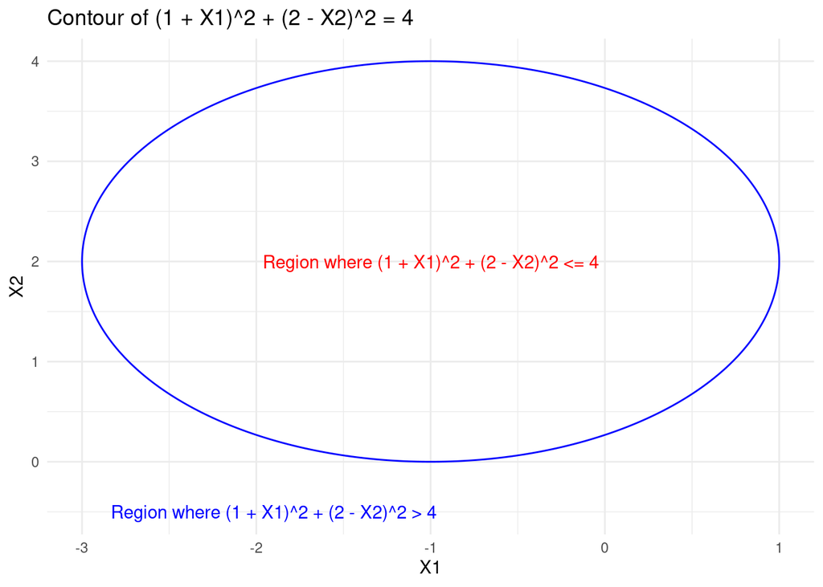

```r
library(ggplot2)

# Function to calculate the circle's radius squared
radius_squared <- function(x, y) {
  (1 + x)^2 + (2 - y)^2
}

# Define the new range for X1 and X2 and create a data frame
x_range <- seq(-6, 4, length.out = 300) # Extended range for X1
y_range <- seq(-2, 6, length.out = 300) # Extended range for X2
df <- expand.grid(X1 = x_range, X2 = y_range)

# Calculate the Z values (the radius squared for each point)
df$Z <- mapply(radius_squared, df$X1, df$X2)

# Plot the contour with the updated ranges
ggplot(df, aes(X1, X2, z = Z)) +
  stat_contour(breaks = 4, colour = "blue") +
  scale_x_continuous(name = "X1") +
  scale_y_continuous(name = "X2") +
  labs(title = "Contour of (1 + X1)^2 + (2 - X2)^2 = 4") +
  annotate("text", x = -1, y = 2, label = "Region where (1 + X1)^2 + (2 - X2)^2 <= 4", color = "red") +
  annotate("text", x = -1.9, y = -0.5, label = "Region where (1 + X1)^2 + (2 - X2)^2 > 4", color = "blue") +
  theme_minimal()
```

3. Suppose that a classifier assigns an observation to the blue class if $(1 + X_1)^2 + (2 − X_2)^2 > 4$, and to the red class otherwise. To what class is the observation (0, 0) classified? (−1, 1)? (2, 2)? (3, 8)?

**Answer:**

The observation (0, 0) is classified as blue because $(1 + 0)^2 + (2 − 0)^2 = 5 > 4$.

The observation (-1, 1) is classified as red because $(1 + (-1))^2 + (2 − 1)^2 = 1 ≤ 4$.

The observation (2, 2) is classified as blue because $(1 + 2)^2 + (2 − 2)^2 = 9 > 4$.

The observation (3, 8) is classified as blue because $(1 + 3)^2 + (2 − 8)^2 = 52 > 4$.

4. Argue that while the decision boundary in (c) is not linear in terms of $X_1 and X_2$, it is linear in terms of $X_1, X_1^2 , X_2, and X_2^2$.

**Answer:**

The decision boundary in (c) is defined by the equation $(1 + X_1)^2 + (2 − X_2)^2 = 4$. This equation can be expanded to the following form:

$$1 + 2X_1 + X_1^2 + 4 - 4X_2 + X_2^2 = 4$$
This equation becomes a linear combination of the terms $X_1, X_1^2 , X_2, and X_2^2$. Therefore, the decision boundary is linear in terms of these variables.